# Topic 7 Exercises: Nonlinear regression

# programming:

# 7.9.11

GAMS: explore backfitting in the context of multiple linear regression.

Suppose that we would like to perform multiple linear regression, but we do not have software to do so. Instead, we only have software to perform simple linear regression. Therefore, we take the following iterative approach: we repeatedly hold all but one coefficient estimate fixed at its current value, and update only that coefficient estimate using a simple linear regression. The process is continued until convergence—that is, until the coefficient estimates stop changing. We now try this out on a toy example

```r
library(ISLR)
library(gam)
```

a.)

```r
set.seed(123)
noise<-rnorm(100)
X1<-rnorm(100)
X2<-rnorm(100)
B1<-4
B2<-9
Y<-B1*X1+B2*X2+noise
```

# keeping B1 constant;

```r
count=1
Bs = matrix(NA,nrow=1000,ncol=3)

for(count in 1:100) {

#pretend x1 doesn't affect y, remove B2 and then solve for X2
a<-Y-B1*X1
B2<-lm(a~X2)$coef[2]

#pretend X2 doesn't affect y, remove B1 and then solve for X2
c<-Y-B2*X2
fit = lm(c~X1)
B1<-lm(c~X1)$coef[2]

B0 = fit$coef[1]

   Bs[count,1] = B0
   Bs[count,2] = B1
   Bs[count,3] = B2
}

Bs[1:100]
```

```
##   [1] 0.1007323 0.1005667 0.1005665 0.1005665 0.1005665 0.1005665 0.1005665
##   [8] 0.1005665 0.1005665 0.1005665 0.1005665 0.1005665 0.1005665 0.1005665
##  [15] 0.1005665 0.1005665 0.1005665 0.1005665 0.1005665 0.1005665 0.1005665
##  [22] 0.1005665 0.1005665 0.1005665 0.1005665 0.1005665 0.1005665 0.1005665
##  [29] 0.1005665 0.1005665 0.1005665 0.1005665 0.1005665 0.1005665 0.1005665
##  [36] 0.1005665 0.1005665 0.1005665 0.1005665 0.1005665 0.1005665 0.1005665
##  [43] 0.1005665 0.1005665 0.1005665 0.1005665 0.1005665 0.1005665 0.1005665
##  [50] 0.1005665 0.1005665 0.1005665 0.1005665 0.1005665 0.1005665 0.1005665
##  [57] 0.1005665 0.1005665 0.1005665 0.1005665 0.1005665 0.1005665 0.1005665
##  [64] 0.1005665 0.1005665 0.1005665 0.1005665 0.1005665 0.1005665 0.1005665
##  [71] 0.1005665 0.1005665 0.1005665 0.1005665 0.1005665 0.1005665 0.1005665
##  [78] 0.1005665 0.1005665 0.1005665 0.1005665 0.1005665 0.1005665 0.1005665
##  [85] 0.1005665 0.1005665 0.1005665 0.1005665 0.1005665 0.1005665 0.1005665
##  [92] 0.1005665 0.1005665 0.1005665 0.1005665 0.1005665 0.1005665 0.1005665
##  [99] 0.1005665 0.1005665
```

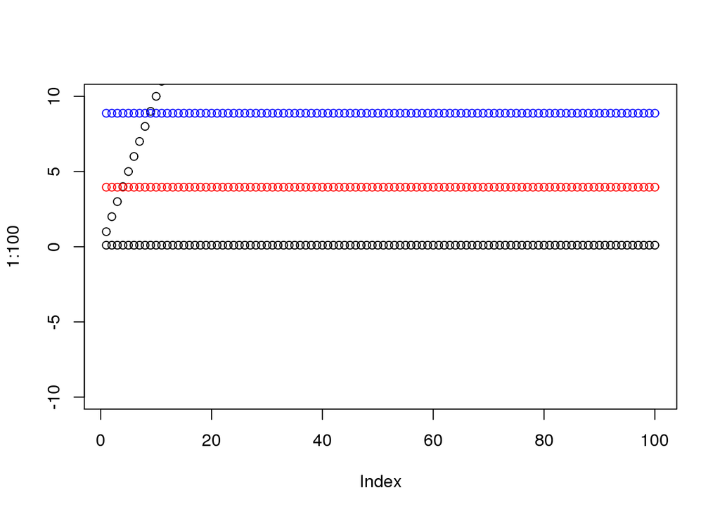

```r
plot(1:100,ylim=c(-10,10))
points(Bs[,1],col="black")
points(Bs[,2],col="red")
points(Bs[,3],col="blue")
```

```r
mod= lm(Y~X1+X2)
coef(mod)
```

```
## (Intercept)          X1          X2
##   0.1005665   3.9569312   8.8772050
```

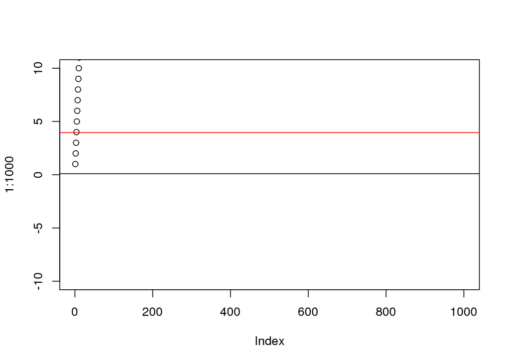

```r
plot(1:1000,ylim=c(-10,10))



abline(h = fit$coef[1],col="black")
abline(h = fit$coef[2], col="red")
abline(h = fit$coef[3], col="blue")
```

- my fits seemed to give a good estimate very quickly…I maybe have done something wrong…I would have expected it to settle out eventualy at the right values, but not start and stay there

# §7.9 problem 3

Suppose we fit a curve with basis functions b1(X) = X, b2(X) = (X − 1)2I(X ≥ 1).

(Note that I(X ≥ 1) equals 1 for X ≥ 1 and 0 otherwise.)

We fit the linear regression model Y = β0 + β1b1(X) + β2b2(X) + error, and obtain coefficient estimates βˆ0 = 1, βˆ1 = 1, βˆ2 = −2. Sketch the estimated curve between X = −2 and X=2.

Note the intercepts,slopes, and other relevant information.

- B0=intercept=1
- linear for -2 to 1, with positive slope. Then quadratic with negative slope
- linear formula = 1 + x
- quad formula = 1 + x + -2* (x-1)^2

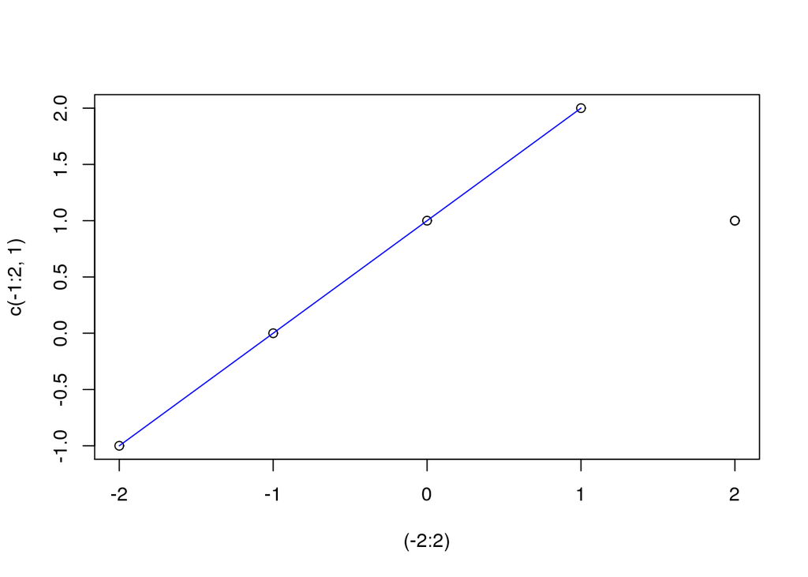

```r
x_points<-c(-2,-1,0,1)
coefs<-c(-1,0,1,2)

plot(x=(-2:2),y=c(-1:2,1))
lines(x_points,coefs,col="blue")
points(x=2,y=1)
```

# §7.9 problem 4

Q4. Suppose we fit a curve with basis functions b1(X)=I(0≤X≤2)−(X−1)I(1≤X≤2)b1(X)=I(0≤X≤2)−(X−1)I(1≤X≤2), b2(X)=(X−3)I(3≤X≤4)+I(4≤X≤5)b2(X)=(X−3)I(3≤X≤4)+I(4≤X≤5).

We fit the linear regression model

Y=β0+β1b1(X)+β2b2(X)+ε,

and obtain coefficient estimates β̂ 0=1, β̂^1=1, β̂^2=3. Sketch the estimated curve between X=−2 and X=2. Note the intercepts, slopes, and other relevant information.

```r
x<-c(-2:2)
B0hat<-c(1,1,1,1,1)
B1hat<-c(1,1,1,1,1)
B2hat<-c(3,3,3,3,3)

b1<-c(0,0,1,1,0)
b2<-c(0,0,0,0,0)

y<-(B0hat+B1hat*b1+B2hat*b2*x)
xyframe<-data.frame(B0hat,B1hat,B2hat,b1,b2,x,y)
```

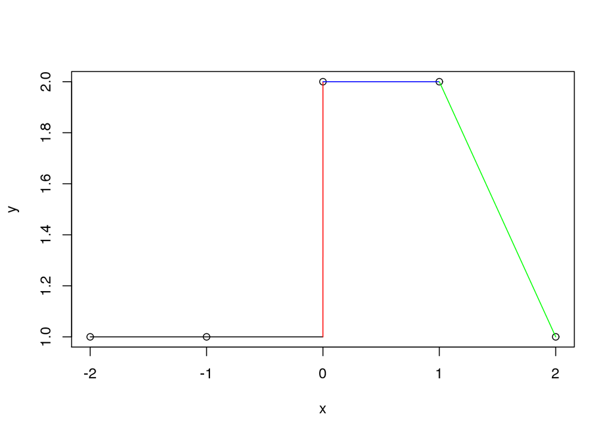

```r
plot(y~x,data=xyframe)
lines(x=c(-2,-1,0),y=c(1,1,1))
lines(x=c(-0.0001,0),y=c(1,2),col="red")
lines(x=c(0,1),y=c(2,2),col="blue")
lines(x=c(1,2),y=c(2,1),col="green")
```

- from x=-2 to x=0 …line is constant with y=1, slope = 0 - from x=0 to x=1 … line is constant with y=2, slope = 0 - from x=1 tp x=2 …..line is linear with y=3-x, slope = -1

# §7.9 problem 5

5. Consider two curves, ˆg1 and ˆg2, defined by g1 has lambda*3d deriv g2 has lambda*4th deriv

(g2 must be smoother or else be penalized)

**(a) As λ → ∞, will ˆg1 or ˆg2 have the smaller training RSS?** - g2 will have the smaller RSS. Lambda approaching infinity puts an increasingly large penalty on “non-smooth-ness” so g2 with the 4th deriv must be as close to perfectly smooth as possible otherwise it will be penalized harshly. This means g2 wil be highly flexible, so I expect g2 to be very ‘good’ at in-sample because it will be so flexible.

**(b) As λ → ∞, will ˆg1 or ˆg2 have the smaller test RSS?** - g1 will have the smaller RSS, following a very similar reason.Since g2 will be highly flexible, it will have high variance because it will be increasingly overfitted to the training data. This will mean it will likely have a very large test RSS.

**(c) For λ = 0, will ˆg1 or ˆg2 have the smaller training and test RSS?** - when lambda is zero, then there isn’t any reason that the two functions will be different, so I’d expect them to have a very similar trining and test RSS